# Introduction to Point Pattern Analysis

Cargo librerias

```r
library(spatstat.core)
library(plotly)
```

Principio de Aceptacion-Rechazo

```r
cuadri <- function(x, y){sqrt(x^2+y^2)/sqrt(8)}
n<-10
x <- y <- seq(0, 2, length= n)
xx<-rep(x,n)
yy<-rep(y,rep(n,n))
z <- outer(x, y, cuadri)
u<-runif(n*n)
graf<-persp(x, y, z,theta = 65,phi=25,zlab="u")
cumplen<-(u<z)
points(trans3d(xx, yy, u,pmat=graf), col = 2+cumplen, pch = 16)
```

```r
#
set.seed(1)
cant<-1000
x<-runif(cant,0,2)
y<-runif(cant,0,2)
u<-runif(cant,0,sqrt(8))
z<-cuadri(x,y)
cumplen<-(u<z)
sum(cumplen)
```

```
[1] 203
```

[figure not shown]

```r
par(pty="s")
```

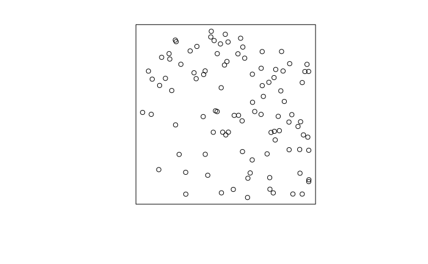

```r
plot(x[cumplen][1:100],y[cumplen][1:100],xlab = "",ylab="",xaxt='n',yaxt='n')
```

Simulacion de Complete Spatial Randomness (CSR) o Independent Random Process (IRP)

(Uniform) Binomial Point Process

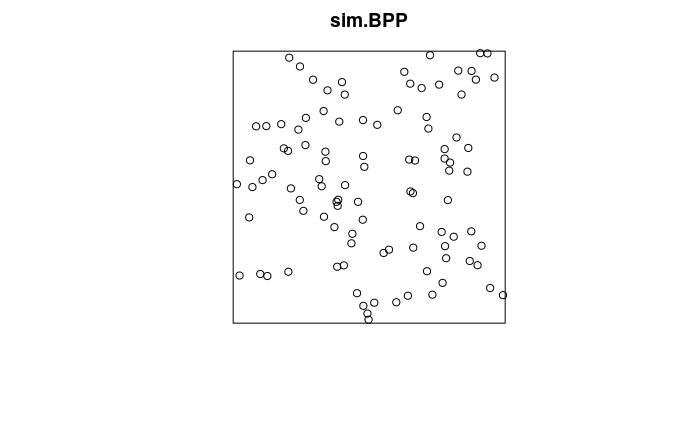

```r
set.seed(1)
cant<-100
sim.BPP<-runifpoint(cant)
plot(sim.BPP)
```

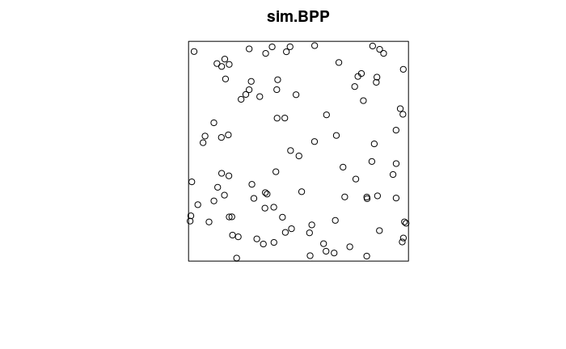

```r
set.seed(2)
sim.BPP<-runifpoint(cant)
plot(sim.BPP)
```

Proceso de poisson homogeneo

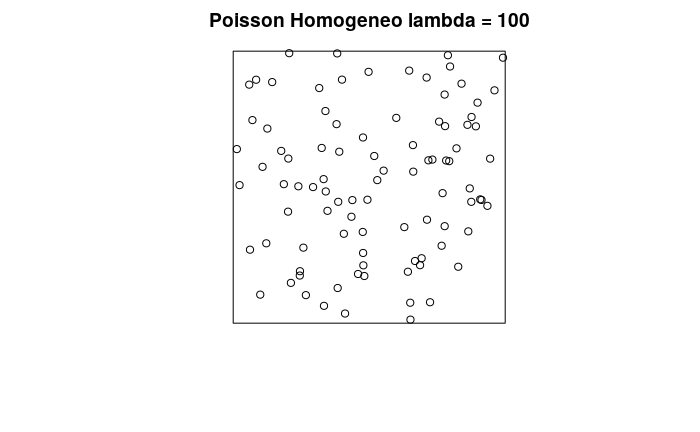

```r
set.seed(1)
lambda<-100
sim.CSR<-rpoispp(lambda)
plot(sim.CSR,main = paste("Poisson Homogeneo lambda =",lambda))
```

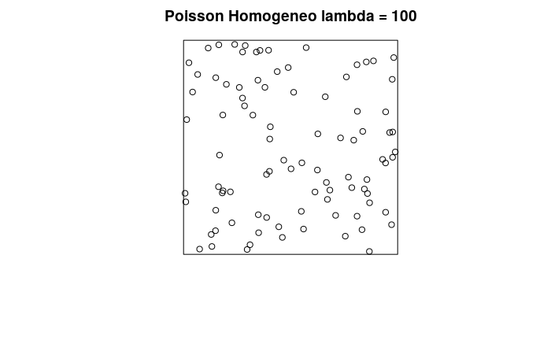

```r
set.seed(2)
lambda<-100
sim.CSR<-rpoispp(lambda)
plot(sim.CSR,main = paste("Poisson Homogeneo lambda =",lambda))
```

Proceso de poisson INhomogeneo

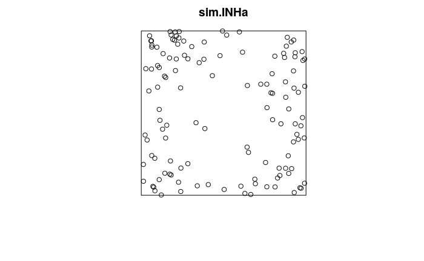

```r
set.seed(1)
sim.INHa <- rpoispp(function(x,y) {800*(x-0.5)^2 + 800*(y-0.5)^2},nsim=1)
plot(sim.INHa)
```

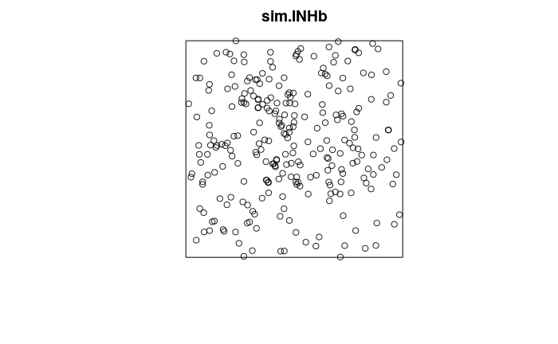

```r
set.seed(1)
sim.INHb <- rpoispp(function(x,y) {200-800*(x-0.5)^2 + 200-800*(y-0.5)^2},nsim=1)
plot(sim.INHb)
```

Proceso de Thomas

```r
par(mfrow=c(2,2))
par(mar=c(1,1,1,1))
set.seed(1)
inten<-30
disper<-0.02
mu<-10
sim.THO <- rThomas(inten,disper,mu)
plot(sim.THO,main=paste("Lambda=",inten,"Mu=",mu,"Sigma=",disper))
set.seed(1)
inten<-30
disper<-0.05
mu<-10
sim.THO <- rThomas(inten,disper,mu)
plot(sim.THO,main=paste("Lambda=",inten,"Mu=",mu,"Sigma=",disper))
```

```r
set.seed(1)
inten<-10
disper<-0.02
mu<-30
sim.THO <- rThomas(inten,disper,mu)
plot(sim.THO,main=paste("Lambda=",inten,"Mu=",mu,"Sigma=",disper))
set.seed(1)
inten<-10
disper<-0.05
mu<-30
sim.THO <- rThomas(inten,disper,mu)
plot(sim.THO,main=paste("Lambda=",inten,"Mu=",mu,"Sigma=",disper))
```

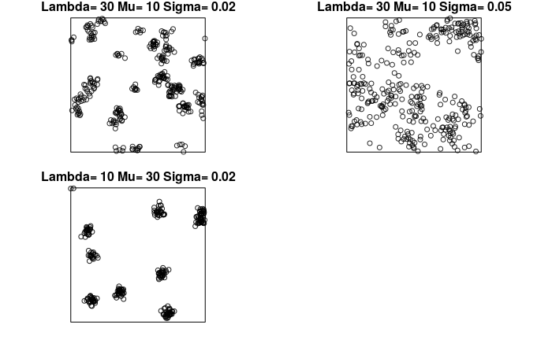

```r
par(mfrow=c(1,1))
```

Proceso de Secuencial Inhibicion Simple (SSI)

```r
par(mfrow=c(2,2))
par(mar=c(1,1,1,1))
set.seed(1)
delta<-0.01
sim.SSI <- rSSI(delta,100)
plot(sim.SSI,main=paste("n=100 delta=",delta))
set.seed(1)
delta<-0.05
sim.SSIa <- rSSI(delta,100)
plot(sim.SSIa,main=paste("n=100 delta=",delta))
```

```r
set.seed(1)
delta<-0.1
sim.SSI <- rSSI(delta,100)
```

```
Gave up after 1000 attempts with only 69 points placed out of 100
```

```r
plot(sim.SSI,main=paste("n=100 delta=",delta))
set.seed(1)
delta<-0.2
sim.SSIb <- rSSI(delta,100)
```

```
Window is too small to fit 100 points at minimum separation 0.2 (absolute maximum number is 31)Gave up after 1000 attempts with only 21 points placed out of 100
```

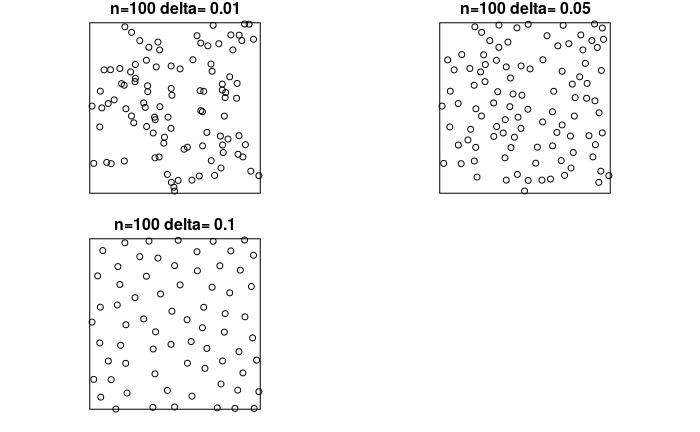

```r
plot(sim.SSIb,main=paste("n=100 delta=",delta))
```

Procesosde COX

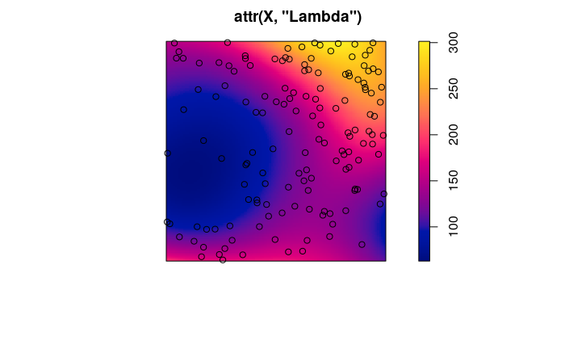

```r
library(RandomFields)
library(RandomFieldsUtils)
 m <- as.im(function(x, y){5 - 1.5 * (x - 0.5)^2 + 2 * (y - 0.5)^2}, W=owin())
 #
X <- rLGCP("gauss", m, var=0.15, scale =0.5)
plot(attr(X, "Lambda"))
points(X)
```

La Funcion G y F en CSR

```r
par(mfrow=c(1,3))
plot(sim.CSR)
env.CSR <- envelope(sim.CSR, fun = Gest, nsim = 200,nrank=5)
```

[output not shown]

```r
plot(env.CSR)
```

```r
env.CSR <- envelope(sim.CSR, fun = Fest, nsim = 200,nrank=5)
```

[output not shown]

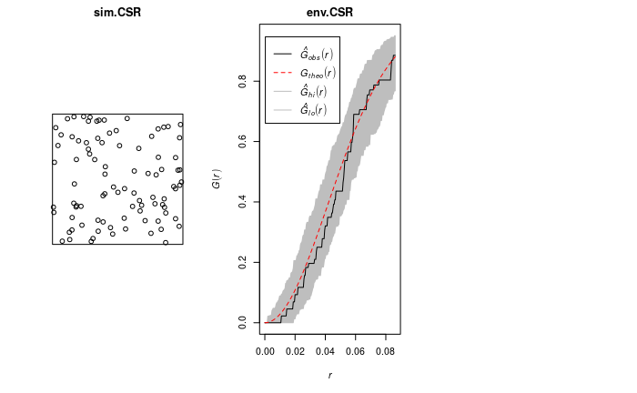

```r
plot(env.CSR)
par(mfrow=c(1,1))
```

La Funcion G y F en Thomas

```r
par(mfrow=c(1,3))
plot(sim.THO)
env.THO <- envelope(sim.THO, fun = Gest, nsim = 200,nrank=5)
```

[output not shown]

```r
plot(env.THO)
```

```r
env.THO <- envelope(sim.THO, fun = Fest, nsim = 200,nrank=5)
```

[output not shown]

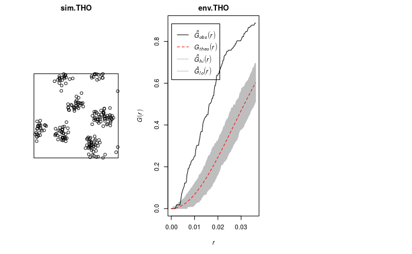

```r
plot(env.THO)
par(mfrow=c(1,1))
```

La Funcion G y F en SSI

```r
par(mfrow=c(1,3))
sim.SSI<-sim.SSIa
plot(sim.SSI)
env.SSI <- envelope(sim.SSI, fun = Gest, nsim = 200,nrank=5)
```

[output not shown]

```r
plot(env.SSI)
```

```r
env.SSI <- envelope(sim.SSI, fun = Fest, nsim = 200,nrank=5)
```

[output not shown]

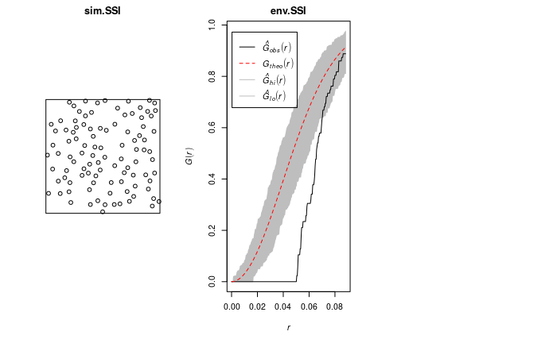

```r
plot(env.SSI)
par(mfrow=c(1,1))
```

```r
par(mfrow=c(1,3))
plot(sim.CSR)
env.CSR <- envelope(sim.CSR, fun = Kest, nsim = 200,nrank=5)
```

[output not shown]

```r
plot(env.CSR)
```

```r
env.CSR <- envelope(sim.CSR, fun = Lest, nsim = 200,nrank=5)
```

[output not shown]

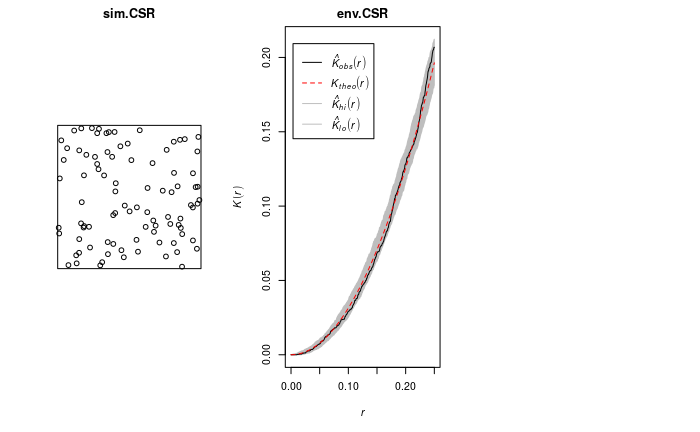

```r
plot(env.CSR, . -r ~ r)
par(mfrow=c(1,1))
```

La Funcion K y L en Thomas

```r
par(mfrow=c(1,3))
plot(sim.THO)
env.THO <- envelope(sim.THO, fun = Kest, nsim = 200,nrank=5)
```

[output not shown]

```r
plot(env.THO)
```

```r
env.THO <- envelope(sim.THO, fun = Lest, nsim = 200,nrank=5)
```

[output not shown]

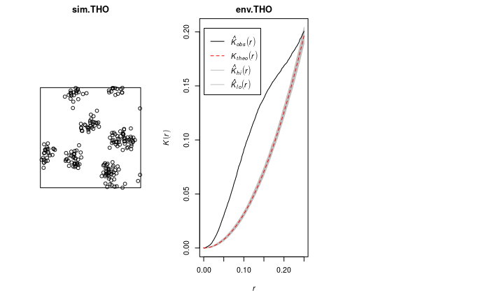

```r
plot(env.THO, . -r ~ r)
par(mfrow=c(1,1))
```

La Funcion K y L en SSI

```r
par(mfrow=c(1,3))
sim.SSI<-sim.SSIa
plot(sim.SSI)
env.SSI <- envelope(sim.SSI, fun = Kest, nsim = 200,nrank=5)
```

[output not shown]

```r
plot(env.SSI)
```

```r
env.SSI <- envelope(sim.SSI, fun = Lest, nsim = 200,nrank=5)
```

[output not shown]

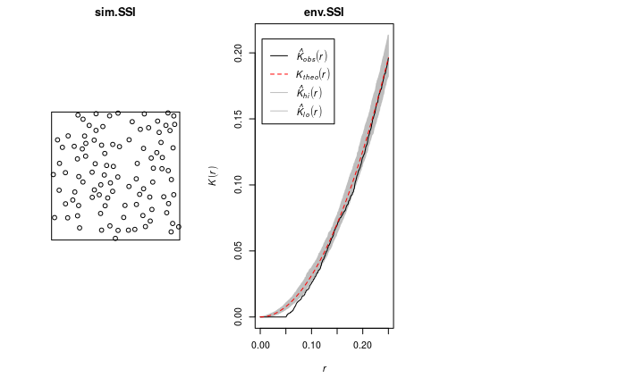

```r
plot(env.SSI, . -r ~ r)
par(mfrow=c(1,1))
```

Como funciona KDE

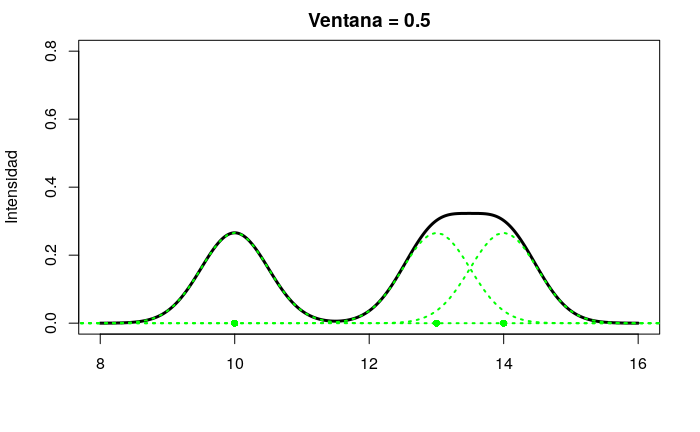

```r
library(manipulate)
x<-c(10,13,14)

GrafKDE<-function(h)
{
plot(density(x,bw=h,from=8,to=16),main=paste("Ventana =",h),ylab="Intensidad",ylim=c(0,0.8),lwd=3,xlab="")
points(x,c(0,0,0),pch=16,col="green")
n1<-function(x){dnorm(x,10,h)/3}
n2<-function(x){dnorm(x,13,h)/3}
n3<-function(x){dnorm(x,14,h)/3}
curve(n1, 7, 17, lwd=2, axes = FALSE, xlab = "", ylab = "",add=T,col="green",lty=3)
curve(n2, 7, 17, lwd=2, axes = FALSE, xlab = "", ylab = "",add=T,col="green",lty=3)
curve(n3, 7, 17, lwd=2, axes = FALSE, xlab = "", ylab = "",add=T,col="green",lty=3)
}
GrafKDE(0.5)
```

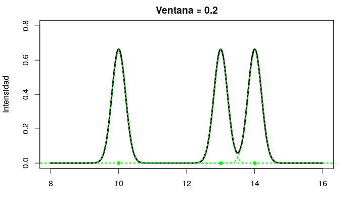

```r
manipulate(GrafKDE(h=h),h=slider(0.2,2,step=0.1))
```

Aplicacion de KDE a Poisson Homogeneo

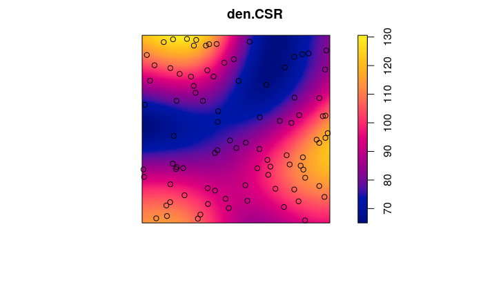

```r
require(splancs)
# eleccion de ventana por diggle
mserw <- bw.diggle(sim.CSR)
bw <- as.numeric(mserw)*3
#
den.CSR<-density(sim.CSR,bw)
plot(den.CSR)
points(sim.CSR)
```

Aplicacion de KDE a Poisson InHomogeneo

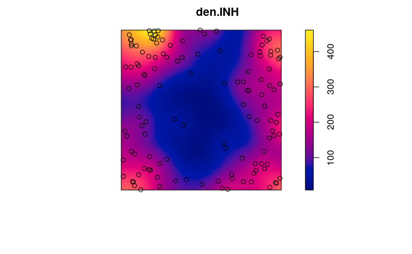

```r
require(splancs)
# eleccion de ventana por diggle
mserw <- bw.diggle(sim.INHa)
bw <- as.numeric(mserw)*3
#
den.INH<-density(sim.INHa,bw)
plot(den.INH)
points(sim.INHa)
```

Elegiendo la ventana optima para Poisson Inhomogeneo

```r
require(spatstat.utils)
#datos<-sim.CSR
datos<-sim.INHa
poligono<-matrix(c(0,0,0,1,1,0,1,1,0,0),4,2,byrow = T)
```

```
data length [10] is not a sub-multiple or multiple of the number of rows [4]
```

```r
Mse2d <- mse2d(as.points(datos), poligono, nsmse=50, range=1)
#png("/home/andresfaral/Dropbox/Estadistica Espacial/KDE INH CV")
plot(Mse2d$h,Mse2d$mse, type="l",xlab="Ventana (h)", ylab="Error Estimado")
arrows(0.15,9,0.15,-1.5,lty=1,col="green",lwd=3)
```

```r
#dev.off()
bw<-min(Mse2d$h)
bw<-0.03
den.INH<-density(datos,bw)
png("/home/andresfaral/Dropbox/Estadistica Espacial/KDE INH chico")
plot(den.INH)
```

[figure not shown]

```r
points(datos)
dev.off()
```

Elegiendo la ventana optima para Thomas

```r
datos<-sim.THO
poligono<-matrix(c(0,0,0,1,1,0,1,1,0,0),4,2,byrow = T)
```

```
data length [10] is not a sub-multiple or multiple of the number of rows [4]
```

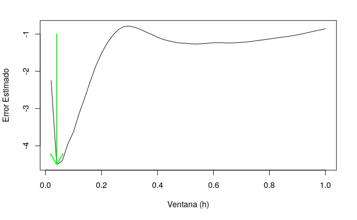

```r
Mse2d <- mse2d(as.points(datos), poligono, nsmse=50, range=1)
bw<-Mse2d$h[which.min(Mse2d$mse)]
#png("/home/andresfaral/Dropbox/Estadistica Espacial/KDE INH CV")
plot(Mse2d$h,Mse2d$mse, type="l",xlab="Ventana (h)", ylab="Error Estimado")
arrows(bw,-1,bw,-4.5,lty=1,col="green",lwd=2)
```

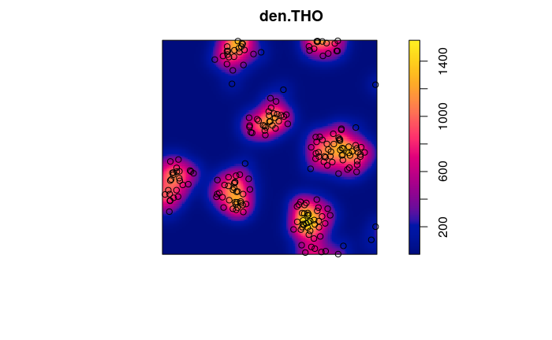

```r
#dev.off()
#bw<-0.03
den.THO<-density(datos,bw)
#png("/hothome/andresfaral/Dropbox/Estadistica Espacial/KDE INH chico")
plot(den.THO)
points(datos)
```

```r
#dev.off()
```

Procesos Marcados

```r
library(gstat)
library(lattice)
library(sp)
data(meuse)
class(meuse)
```

```
[1] "data.frame"
```

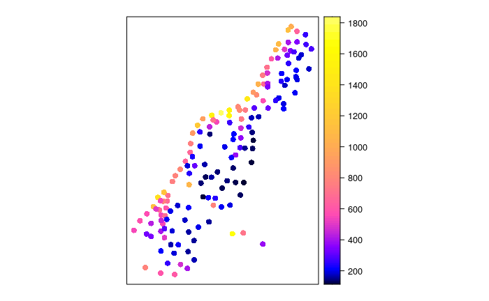

```r
coordinates(meuse) <- c("x", "y")
# EDA
spplot(meuse, "zinc", do.log = T, colorkey = TRUE)
```

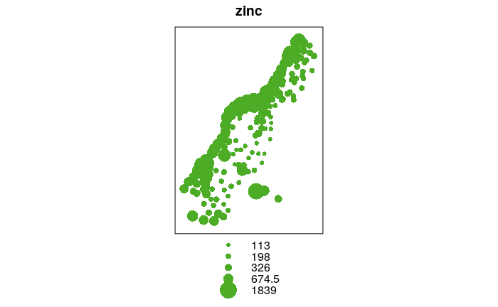

```r
bubble(meuse, "zinc", do.log = T, key.space = "bottom")
```

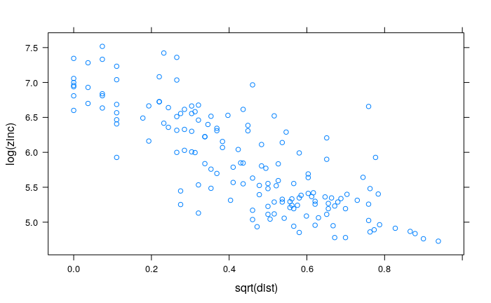

```r
# fitting
xyplot(log(zinc) ~ sqrt(dist), as.data.frame(meuse))
```

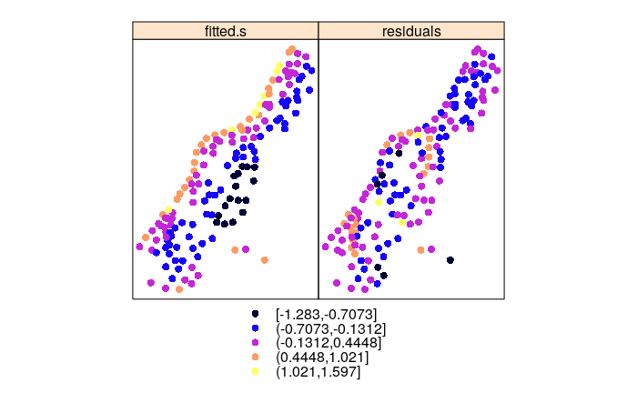

```r
zn.lm <- lm(log(zinc) ~ sqrt(dist), meuse)
meuse$fitted.s <- predict(zn.lm, meuse) - mean(predict(zn.lm,
meuse))
meuse$residuals <- residuals(zn.lm)
spplot(meuse, c("fitted.s", "residuals"))
```

```r
class(meuse.grid)
```

```
[1] "data.frame"
```

Interpolacion con Modelado Lineal

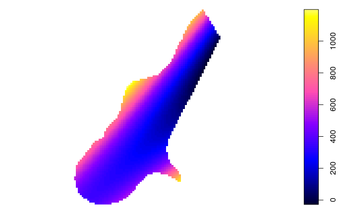

```r
#zn.lm <- lm(log(zinc) ~ sqrt(dist), meuse)
#zn.lm <- lm(zinc ~ sqrt(dist), meuse)
zn.lm <- lm(zinc ~ poly(x, y, degree = 2), meuse)
meuse.grid$pred <- predict(zn.lm, meuse.grid)
meuse.grid$se.fit <- predict(zn.lm, meuse.grid, se.fit = TRUE)$se.fit
plot(meuse.grid["pred"])
```